# Scalable Bayesian Inference for Streaming Data

12th January 2017

## Motivation: Online Inference for Streaming Data

### Starting Point

- Learn about processes which evolve in time
- Make predictions about future observations
- Interpolate missing data

### Next Steps

- Model different related processes

## The Urban Observatory

[interactive chart not shown]

## Streaming Data from the Urban Observatory

- Streaming data is typically heterogeneous and irregularly observed
- Dynamic Linear Models have support for missing data but can't easily support irregularly observed data

| timestamp | CO | Humidity | NO | NO2 | Temperature |
| --- | --- | --- | --- | --- | --- |
| 2016-11-01 23:55:01 | 0 | 84.5 | 17.3 | 65.0 | 4.2 |
| 2016-11-01 23:56:01 | 0 | 84.5 | 15.6 | 64.8 | 4.2 |
| 2016-11-01 23:57:02 | 0 | 84.5 | 14.0 | 64.7 | 4.2 |
| 2016-11-01 23:58:02 | 0 | 84.5 | 12.6 | 64.6 | 4.2 |
| 2016-11-01 23:59:02 | 0 | 84.5 | 11.4 | 64.2 | 4.2 |

## Streaming Data from the Urban Observatory

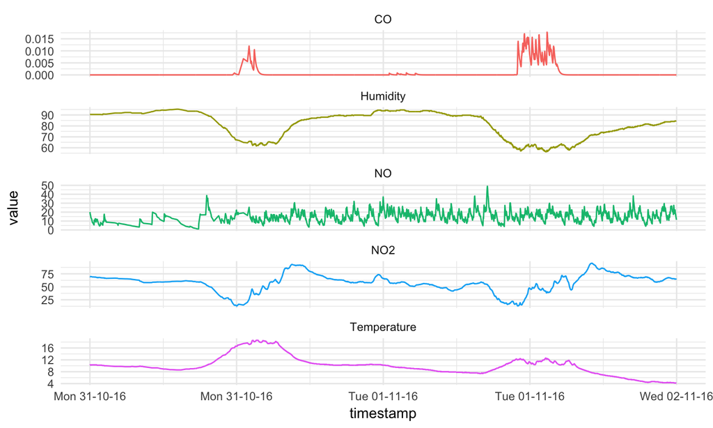

## Univariate Online Analysis: POMP Model

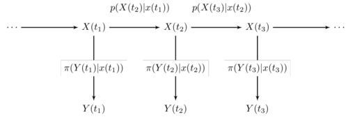

- \(X_1,X_2,\dots,X_k,\dots\) is a markov process, represented by a diffusion process
- The diffusion process can be simulated at irregular intervals
- \(Y_k\) only depends on \(X_k\) via an observation distribution, \(Y_k \sim \pi(Y_k | X_k = x_k)\)
- The observation distribution is flexible

## Inference for POMP Models

- Determine the state, \(X_1,\dots,X_k\), given observations, \(y_1,\dots,y_k\)
- Batch algorithms, such as MCMC determine the posterior distribution of the state given observations
- If a new observation arrives at time \(t = k+1\), the MCMC must be re-run
- Sequential Monte Carlo methods can be used to estimate the filtering distribution (and parameters) online

## Scalable Inference for POMP Models

- Sequential Monte Carlo (SMC) methods are scalable
- Can be used to calculate the state and parameters online

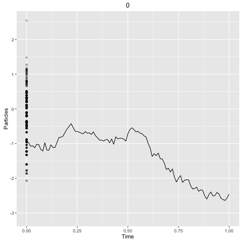

## Modelling Related Processes

## Humidity and Temperature

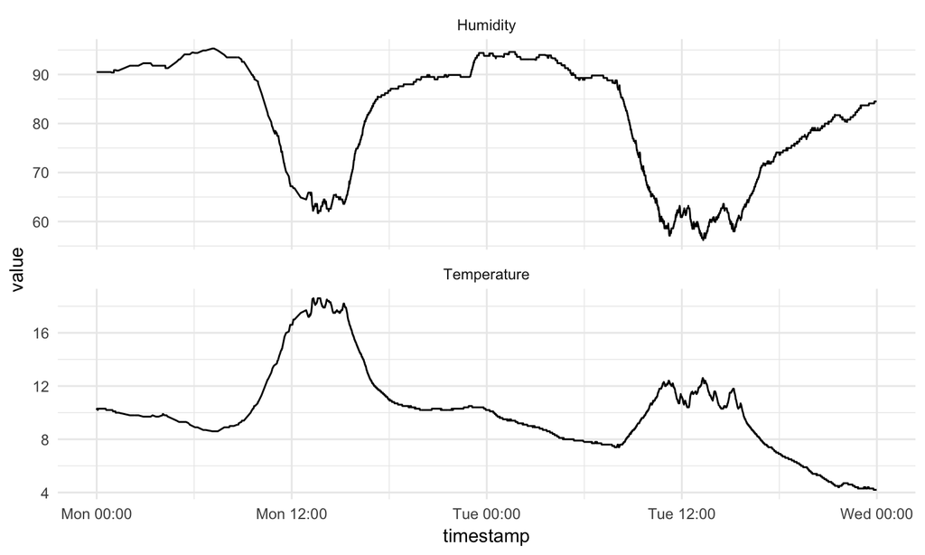

## Modelling Related Time Series

\[\begin{align*} \textbf{Y}(t_i)|\textbf{x}(t_i)) &\sim \pi(\textbf{Y}(t_i)|\textbf{x}(t_i)) \\ \textbf{X}(t_i) | \textbf{x}(t_{i-1}) &\sim p(\textbf{X}(t_i) | \textbf{x}(t_{i-1})) \end{align*}\]

- A single observation at time \(t\) is now a vector with \(k\) components, \(\textbf{Y}(t_i) = (Y_1(t_i), \dots, Y_k(t_i))^T\)
- The observation distribution is now multivariate
- Dependence between time series can be induced by having non-diagonal observation variance-covariance matrices

## Functional Programming in Scala: Advantages

- Referentially transparent functions
- Function composition
- Futures and Streams for efficient asynchronous programming
- Higher order abstractions (Functors, Applicatives, Monads etc) enabling greater level of code reuse
- Property Based Testing
- Runs on the JVM - access to Java librarys, deploy everywhere
- Fully Features dependency management and build tool (SBT)
- Mature statistical and numerical computing libraries (Breeze, Spire)

## Summary

### What I've done so far

- Made a library for inference of Composable Univariate POMP models: git.io/statespace

### Further Work

- Extend POMP models to multivariate (heterogeneous) observations
- Scalable, online inference for multivariate POMP models